# STA5703 hw 4

Thien Pham

2023-10-07

# Evaluating Regression Supervised Learning Model Quality

## Preparing workspace

```r
options(
  digits = 2,
  scipen = 999,
  warn = -1
)
rm(
  list = ls()
)
library(magrittr)
```

## Loading data

```r
sephora <- readr::read_csv(
  file = "/Users/thienpham/Data Mining/data/prepared_sephora.csv",
  col_types = "nnnnnnnnnnnnn"
)
```

## Partitioning data

```r
set.seed(1)
# Create a new column called Partition using the sampling technique to assign a label to each row
sephora$Partition <- sample(
  x = c("train","validation","test"),                   # a random sample of "train", "validation", and "test"
  size = nrow(sephora),                            # equal to the # of rows of our data
  replace = TRUE,                                       # with replacement
  prob = c(0.7,0.15,0.15)                               # where we want 75% of the data to be "train" ...
)
# Split sephora data by the partition we made
list_sephora <- split(
  x = sephora,
  f = sephora$Partition
)
str(
  object = list_sephora,
  max.level = 1
)
```

```
## List of 3
##  $ test      : tibble [1,350 × 16] (S3: tbl_df/tbl/data.frame)
##  $ train     : tibble [6,382 × 16] (S3: tbl_df/tbl/data.frame)
##  $ validation: tibble [1,436 × 16] (S3: tbl_df/tbl/data.frame)
```

## Fitting linear regression model

```r
lm_sephora <- lm(
  formula = YJ_love ~ brand + category + rating + number_of_reviews + price + value_price +
            MarketingFlags + online_only + exclusive + limited_edition + limited_time_offer,
  data = sephora %>%
    dplyr::filter(
      Partition == "train"
    )
)
lm_sephora
```

```
##
## Call:
## lm(formula = YJ_love ~ brand + category + rating + number_of_reviews +
##     price + value_price + MarketingFlags + online_only + exclusive +
##     limited_edition + limited_time_offer, data = sephora %>%
##     dplyr::filter(Partition == "train"))
##
## Coefficients:
##        (Intercept)               brand            category              rating
##           10.64968             2.83711             2.28860             1.56528
##  number_of_reviews               price         value_price      MarketingFlags
##            0.00205            -0.61480             0.91404             0.82495
##        online_only           exclusive     limited_edition  limited_time_offer
##           -1.14339             0.71628            -0.64398             0.31132
```

# Metrics for Regression Models

## MSE, RMSE, MAE

```r
# Residual calculation is reversed here: positive = big, negative = small
sephora <- sephora %>%
  dplyr::mutate(
    predict = predict(
      object = lm_sephora,
      newdata = sephora
    ),
    residual = predict - YJ_love
  )


sephora %>%
  dplyr::group_by(Partition) %>%
  dplyr::summarise(
    mean_squared_error = mean((residual)^2),
    root_mean_squared_error = sqrt(mean_squared_error),
    mean_absolute_error = mean(abs(residual))
  )
```

```
## # A tibble: 3 × 4
##   Partition  mean_squared_error root_mean_squared_error mean_absolute_error
##   <chr>                   <dbl>                   <dbl>               <dbl>
## 1 test                     15.6                    3.96                2.95
## 2 train                    16.3                    4.03                2.97
## 3 validation               15.9                    3.98                2.97
```

Our results here are not what we are looking for. The residuals are tight but the train statistic is worse than the validation statistics, and validation worse than test. It should be the other way around.

## Correlation between Target Variable and Predicted Values

```r
cor(
  x = sephora %>%
    dplyr::select(YJ_love,predict)
)
```

```
##         YJ_love predict
## YJ_love    1.00    0.66
## predict    0.66    1.00
```

We see a .66 correlation between our model values and our actual target variable.

## AIC BIC

```r
AIC(
  object = lm_sephora
)
```

```
## [1] 35932
```

```r
BIC(
  object = lm_sephora
)
```

```
## [1] 36019
```

These AIC and BIC values are pretty big. This current full model could improve based on some future feature selection methods.

## Scatterplot of the Target Variable by Predicted Target Values

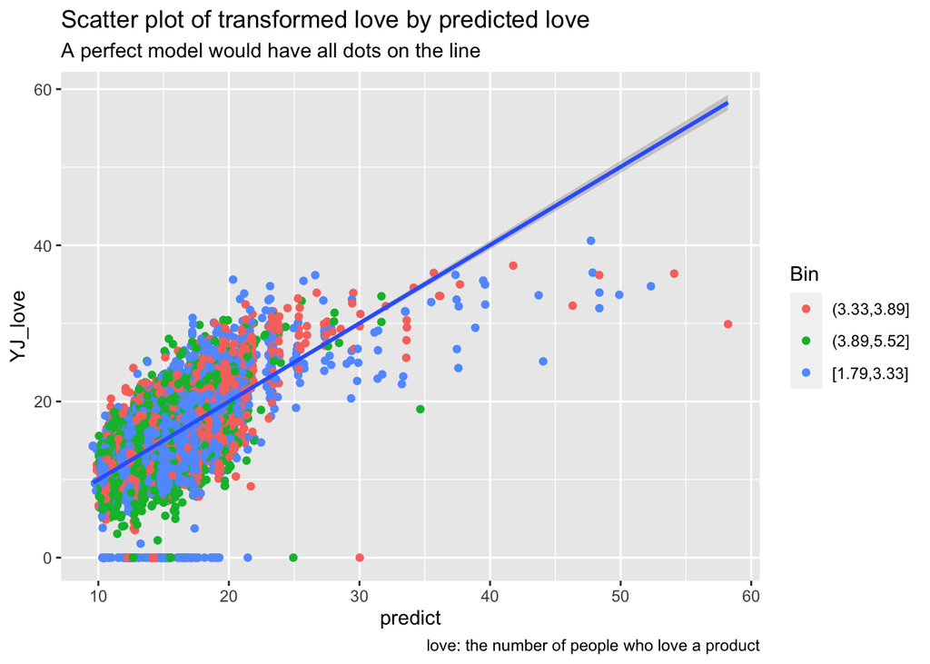

```r
library(ggplot2)
ggplot(sephora) +
  aes(x = predict,y = YJ_love) +
  geom_point(mapping = aes(color = Bin)) +
  geom_smooth(method = "lm") +
  labs(
    title = "Scatter plot of transformed love by predicted love",
    subtitle = "A perfect model would have all dots on the line",
    caption = "love: the number of people who love a product"
  )
```

This is a terrible looking model based on this plot.

## Vigintile/Decile Plot

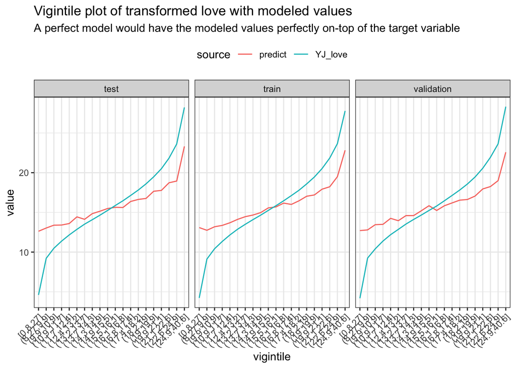

```r
sephora_plot <- sephora %>%
  dplyr::mutate(
    vigintile = cut_number(YJ_love,n = 20)
  ) %>%
  dplyr::group_by(vigintile,Partition) %>%
  dplyr::summarise(
    YJ_love = mean(YJ_love),
    predict = mean(predict)
  ) %>%
  tidyr::gather(key = "source",value = "value",YJ_love,predict) %>%
  dplyr::ungroup() %>%
  as.data.frame()
ggplot(sephora_plot) +
  aes(x = vigintile,y = value,color = source,group = source) +
  geom_line() +
  facet_grid(~Partition) +
  theme_bw() +
  theme(axis.text.x = element_text(angle = 45, vjust = 1, hjust=1),legend.position = "top") +
  labs(
    title = "Vigintile plot of transformed love with modeled values",
    subtitle = "A perfect model would have the modeled values perfectly on-top of the target variable"
  )
```

This is far from a perfect model but at least the shape is correct.

## Boxplots of target and predicted values by bin

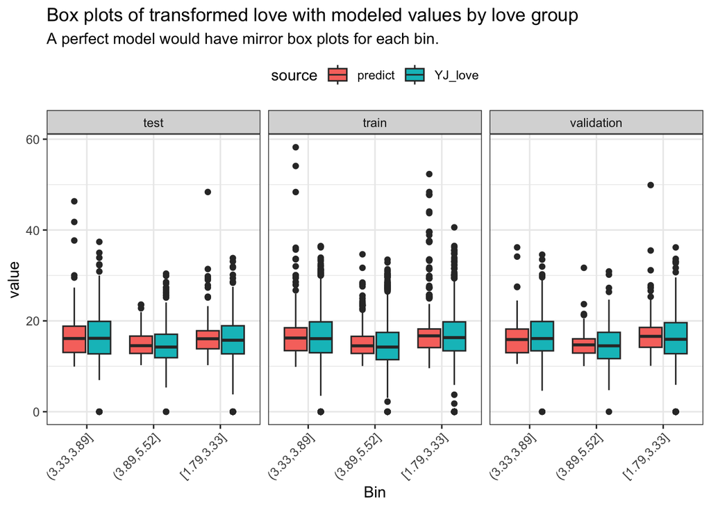

```r
sephora_plot <- sephora %>%
  dplyr::mutate(
    vigintile = cut_number(YJ_love,n = 20)
  ) %>%
  dplyr::select(YJ_love,predict,Bin,Partition,vigintile) %>%
  tidyr::gather(key = "source",value = "value",YJ_love,predict)


ggplot(sephora_plot) +
  aes(x = Bin,fill = source,y = value) +
  geom_boxplot() +
  facet_grid(~Partition) +
  theme_bw() +
  theme(axis.text.x = element_text(angle = 45, vjust = 1, hjust=1),legend.position = "top") +
  labs(
    title = "Box plots of transformed love with modeled values by love group",
    subtitle = "A perfect model would have mirror box plots for each bin."
  )
```

The distribution of the actual and predicted values within each bin matches up along the median but the boxes themselves do not appear close.

Overall, from observing the residuals, AIC, BIC values and all of the plots, it is clear that our current model, the full model is not a good model. The residuals statistics were in reverse order for the training, validation, and test sets. The AIC and BIC values were large. This is expected since we would still need to go through feature selection in order to improve the model.